# Chap9.9

Mijeong Kim

```r
library(tsibble)
library(tsibbledata)
library(tibble)
library(dplyr)
library(knitr)
library(ggplot2)
library(fpp3)
library(fpp2)
library(seasonal)
library(feasts)
```

## 9.9 Seasonal ARIMA models (계절형 ARIMA 모델)

ARIMA 모델은 비계절형 데이터뿐 아니라 계절성이 있는 시계열 데이터도 모형화할 수 있다. 계절형 ARIMA 모델은 기존 ARIMA 모델에 계절 성분을 추가한 형태이며 다음과 같이 표현된다.

$$ARIMA(p, d, q)(P, D, Q)_m$$

- 소문자: 비계절 성분
- 대문자: 계절 성분
- $m$: 계절 주기 (예: 월별 데이터는 $m=12$, 분기별은 $m=4$)

계절 성분은 비계절 성분과 유사하지만, 시차가 $m$인 시점과의 관계를 나타낸다.

예를 들어, ARIMA(1,1,1)(1,1,1)_4 모델은 다음과 같이 쓸 수 있다.

$$(1 - \phi_1 B)(1 - \Phi_1 B^4)(1 - B)(1 - B^4) y_t = (1 + \theta_1 B)(1
+ \Theta_1 B^4) \varepsilon_t$$

계절 성분과 비계절 성분은 곱해지는 형태로 구성된다.

### ACF와 PACF

계절형 AR 또는 MA 모델은 **계절 지연값(seasonal lags)**에서 그 특성이 나타난다.

#### 예시 1: ARIMA(0,0,0)(0,0,1)_12

- ACF: 시차 12에서 하나의 큰 spike
- PACF: 12, 24, 36…에서 지수적 감소

#### 예시 2: ARIMA(0,0,0)(1,0,0)_12

- ACF: 12, 24, 36…에서 지수적 감소
- PACF: 시차 12에서 하나의 큰 spike

#### 모델링 절차

모델링 절차는 비계절형 ARIMA와 유사하지만, 계절형 AR 및 MA 항도 함께 고려해야 한다. 계절형 ARIMA 모형 선택 시에는 **계절 지연값에 집중**하는 것이 중요하다.

### Example: Monthly US leisure and hospitality employment

2001년 1월부터 2019년 9월까지의 미국 월별 여가 및 환대 업종 고용 데이터를 사용하여 계절형 ARIMA 모델링을 설명할 것이다. 이 데이터는 그림 9.18에 나와 있다.

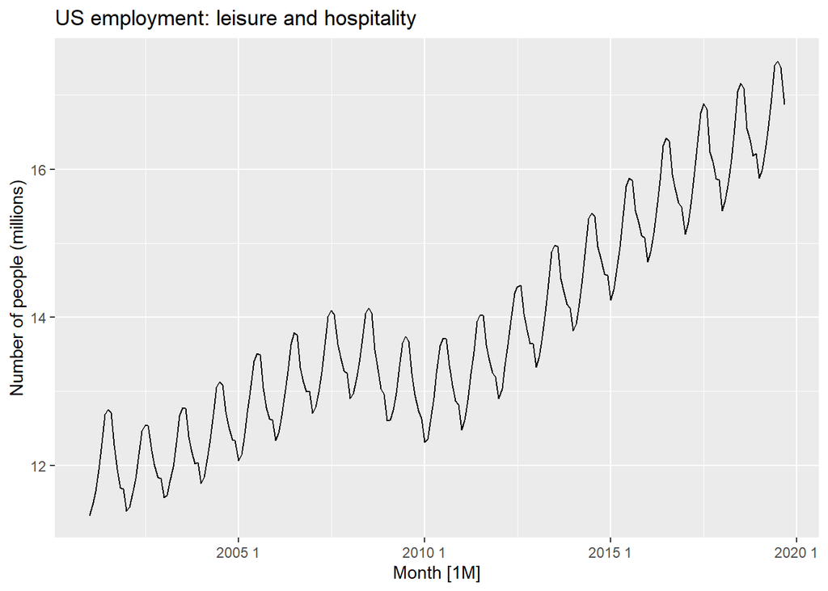

```r
leisure <- us_employment |>
  filter(Title == "Leisure and Hospitality",
         year(Month) > 2000) |>
  mutate(Employed = Employed/1000) |>
  select(Month, Employed)
autoplot(leisure, Employed) +
  labs(title = "US employment: leisure and hospitality",
       y="Number of people (millions)")
```

Figure 9.18: Monthly US leisure and hospitality employment, 2001-2019.

데이터는 뚜렷한 비정상성을 보이며, 강한 계절성과 비선형 추세를 포함하고 있다. 따라서 먼저 계절 차분을 적용할 것이다. 계절 차분된 데이터는 그림 9.19에 제시되어 있다.

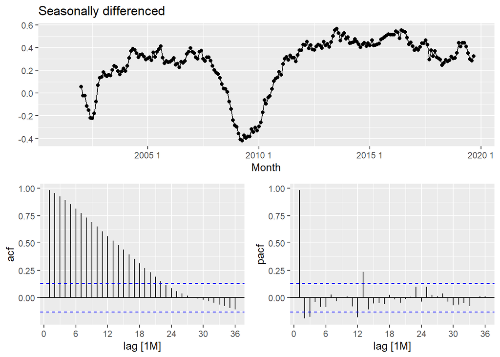

```r
leisure |>
  gg_tsdisplay(difference(Employed, 12),
               plot_type='partial', lag=36) +
  labs(title="Seasonally differenced", y="")
```

Figure 9.19: Seasonally differenced Monthly US leisure and hospitality employment.

뚜렷한 비정상성을 보이므로, 그림 9.20에서는 한 번 더 1차 차분을 적용한다.

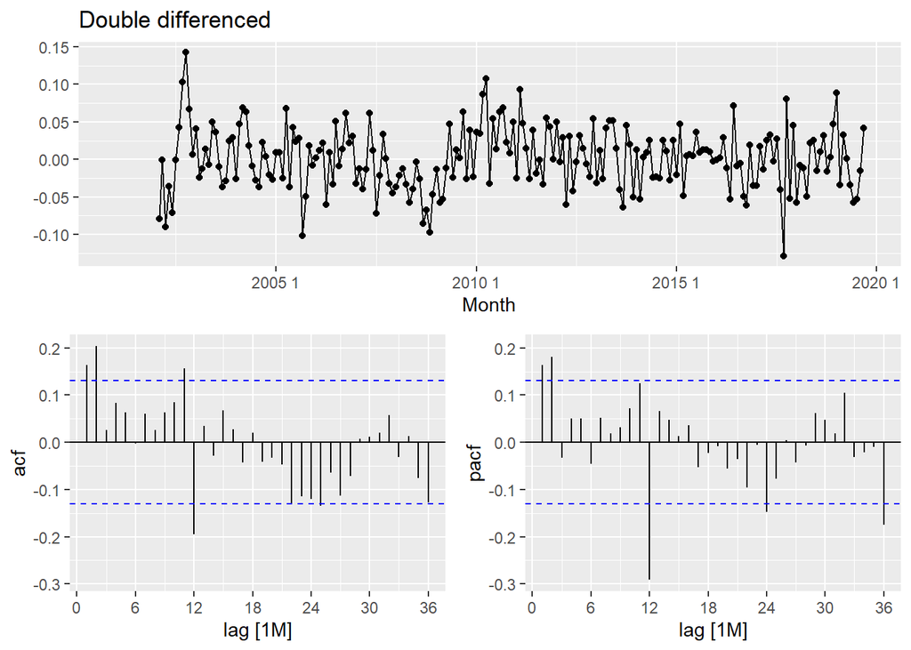

```r
leisure |>
  gg_tsdisplay(difference(Employed, 12) |> difference(),
               plot_type='partial', lag=36) +
  labs(title = "Double differenced", y="")
```

Figure 9.20: Double differenced Monthly US leisure and hospitality employment.

현재 목표는 그림 9.20의 ACF 및 PACF를 바탕으로 적절한 ARIMA 모형을 찾는 것이다.

- ACF의 시차 2에서 유의미한 스파이크는 비계절형 MA(2) 성분을 시사한다.
- 시차 12의 스파이크는 계절형 MA(1) 성분을 나타낸다. → 이에 따라, ARIMA(0,1,2)(0,1,1)\₁₂ 모델을 초기 후보로 설정한다. 이 모델은 1차 차분, 계절 차분, 비계절형 MA(2), 계절형 MA(1) 성분을 포함한다.

PACF를 먼저 고려했다면 ARIMA(2,1,0)(0,1,1)\₁₂ 모델을 선택했을 수도 있다.

- 즉, PACF는 비계절 성분, ACF는 계절 성분 결정에 활용될 수 있다.

또한 자동 선택 모델도 포함할 예정이며,

- stepwise = FALSE, approximation = FALSE 설정을 통해 R이 최적의 모델을 찾도록 한다.

```r
fit <- leisure |>
  model(
    arima012011 = ARIMA(Employed ~ pdq(0,1,2) + PDQ(0,1,1)),
    arima210011 = ARIMA(Employed ~ pdq(2,1,0) + PDQ(0,1,1)),
    auto = ARIMA(Employed, stepwise = FALSE, approx = FALSE)
  )
fit |> pivot_longer(everything(), names_to = "Model name",
                     values_to = "Orders")
```

```
## # A mable: 3 x 2
## # Key:     Model name [3]
##   `Model name`                    Orders
##   <chr>                          <model>
## 1 arima012011  <ARIMA(0,1,2)(0,1,1)[12]>
## 2 arima210011  <ARIMA(2,1,0)(0,1,1)[12]>
## 3 auto         <ARIMA(2,1,0)(1,1,1)[12]>
```

#### 1. 차분(d, D) 자동 결정

`ARIMA()` 함수는 다음 함수를 이용해 차분 횟수를 자동으로 결정한다:

- 계절 차분 $D$: `unitroot_nsdiffs()`
- 일반 차분 $d$: `unitroot_ndiffs()`

사용자가 직접 지정하지 않으면, 위 함수들이 데이터의 비정상성을 진단하여 차분 횟수를 판단한다.

#### 2. 모수 선택 ($p, q, P, Q$)

비계절 ARIMA 모델과 마찬가지로, 모수는 **AICc 값을 최소화**하는 기준으로 자동 선택된다.

#### 3. 모델 비교

- **ARIMA(0,1,2)(0,1,1)$_{12}$** : ACF 기반 선택
- **ARIMA(2,1,0)(0,1,1)$_{12}$** : PACF 기반 대안 모델
- **ARIMA(2,1,0)(1,1,1)$_{12}$** : 자동 선택 모델 (가장 우수)

→ 두 번째 수동 모델이 자동 모델과 매우 유사하게 나타났다.

## 4. 최적 모델의 진단

최종 선택된 모델 **ARIMA(2,1,0)(1,1,1)$_{12}$**의 잔차는 다음 조건을 만족해야 한다:

- 랜덤한 분포
- 평균 0
- 자기상관 없음

**잔차 진단 그래프는 그림 9.21에 표시된다.**

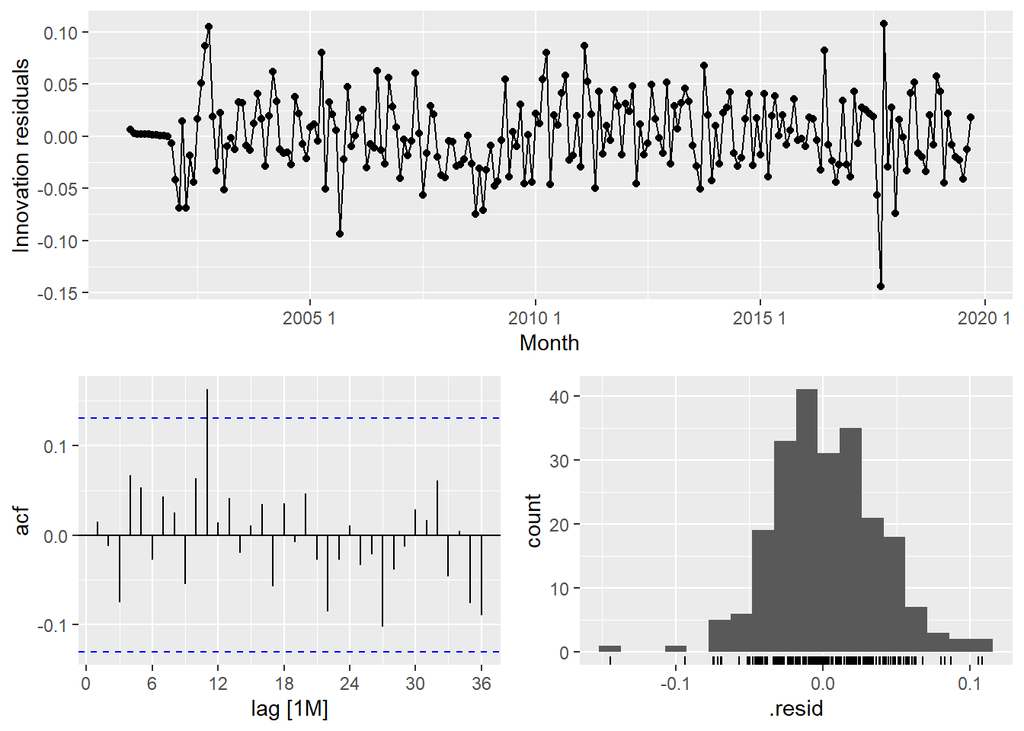

```r
fit |> select(auto) |> gg_tsresiduals(lag=36)
```

Figure 9.21: Residuals from the fitted ARIMA(2,1,0)(1,1,1)$_{12}$ model.

```r
augment(fit) |>
  filter(.model == "auto") |>
  features(.innov, ljung_box, lag=24, dof=4)
```

```
## # A tibble: 1 × 3
##   .model lb_stat lb_pvalue
##   <chr>    <dbl>     <dbl>
## 1 auto      16.6     0.680
```

Ljung-Box 검정의 p-값이 크게 나타나, 잔차가 백색잡음과 유사함을 확인할 수 있다.

따라서 필요한 검정을 통과한 계절형 ARIMA 모델이 완성되었으며, 이제 예측에 활용할 준비가 되었다.

- 3년 후까지의 예측값은 그림 9.22에 제시되어 있다.
- 예측은 계절 패턴을 잘 반영하고 있으며, 최근 추세를 이어가는 상승 경향도 나타낸다.
- 이 예측 추세는 **이중 차분(double differencing)**에 의해 유도된 것이다.

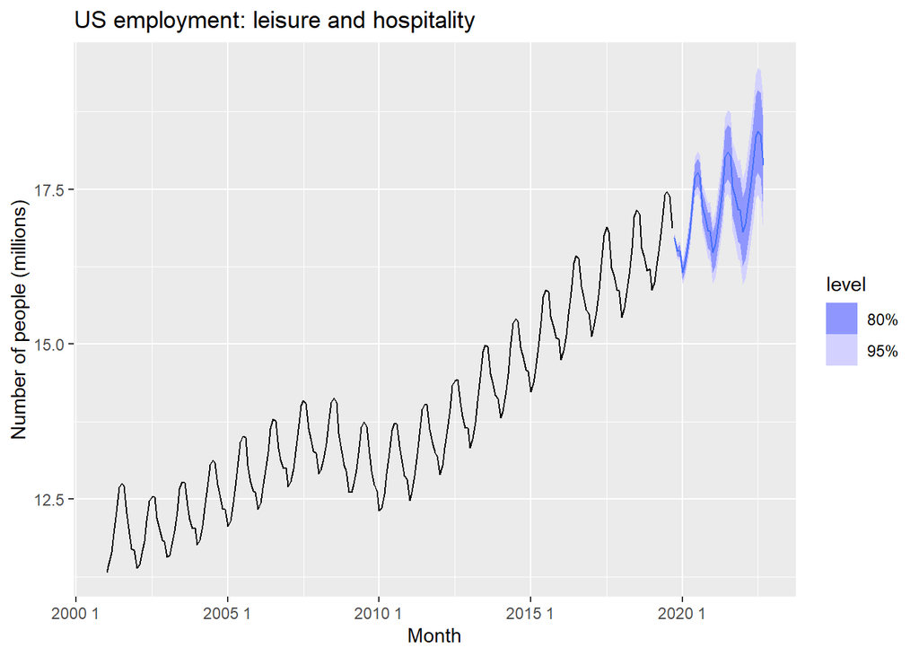

```r
forecast(fit, h=36) |>
  filter(.model=='auto') |>
  autoplot(leisure) +
  labs(title = "US employment: leisure and hospitality",
       y="Number of people (millions)")
```

Figure 9.22: Forecasts of monthly US leisure and hospitality employment using the ARIMA(2,1,0)(1,1,1)$_{12}$ model. 80% and 95% prediction intervals are shown.

### Example: Corticosteroid drug sales in Australia

두 번째 예제로는 호주의 월별 코르티코스테로이드 의약품 판매량 예측을 다룬다. 이 의약품은 ATC 분류 체계상 H02 약물로 분류된다.

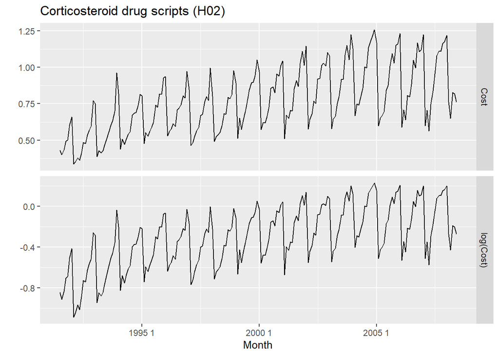

```r
h02 <- PBS |>
  filter(ATC2 == "H02") |>
  summarise(Cost = sum(Cost)/1e6)
h02 |>
  mutate(log(Cost)) |>
  pivot_longer(-Month) |>
  ggplot(aes(x = Month, y = value)) +
  geom_line() +
  facet_grid(name ~ ., scales = "free_y") +
  labs(y="", title="Corticosteroid drug scripts (H02)")
```

Figure 9.23: Corticosteroid drug sales in Australia (in millions of scripts per month). Logged data shown in bottom panel.

1991년 7월부터 2008년 6월까지의 코르티코스테로이드 판매량 데이터는 그림 9.23에 제시되어 있다. 데이터 수준이 높아질수록 분산이 약간 증가하므로, 분산 안정화를 위해 로그 변환을 적용한다.

데이터는 강한 계절성과 명확한 비정상성을 보이므로, 계절 차분을 실시하고, 차분된 결과는 그림 9.24에 나타나 있다. 추가 차분 여부는 명확하지 않지만, 차분을 더 하지 않기로 결정한다.

또한 최근 몇 개의 관측값이 이전보다 더 변동성이 크며 다르게 보이는데, 이는 보고 지연으로 인한 데이터 수정 가능성 때문일 수 있다.

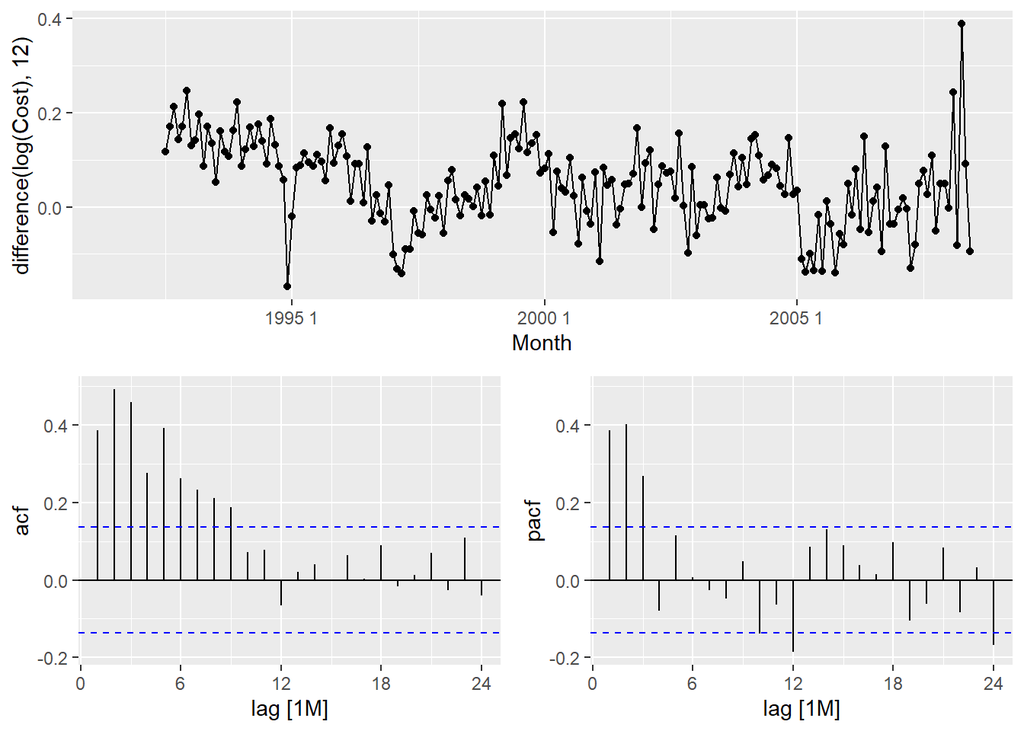

```r
h02 |> gg_tsdisplay(difference(log(Cost), 12),
                     plot_type='partial', lag_max = 24)
```

Figure 9.24: Seasonally differenced corticosteroid drug sales in Australia (in millions of scripts per month).

#### 모델 후보 도출: ACF/PACF 분석

- **계절 차분된 데이터의 PACF**에서 **시차 12, 24**에 스파이크 → **계절형 AR(2)** 가능성 제시
- **비계절 PACF**에서 시차 1, 2, 3에서 유의미한 스파이크 → **비계절형 AR(3)** 가능성
- ACF는 특정 모형을 제시하지 않음

**→ 초기 모델 후보**: `ARIMA(3,0,0)(2,1,0)[12]`

#### 다양한 모델의 AICc 비교

| 모델 | AICc |
| --- | --- |
| ARIMA(3,0,1)(0,1,2)[12] | **-485.5** |
| ARIMA(3,0,1)(1,1,1)[12] | -484.2 |
| ARIMA(3,0,1)(0,1,1)[12] | -483.7 |
| ARIMA(3,0,1)(2,1,0)[12] | -476.3 |
| ARIMA(3,0,0)(2,1,0)[12] | -475.1 |
| ARIMA(3,0,2)(2,1,0)[12] | -474.9 |
| ARIMA(3,0,1)(1,1,0)[12] | -463.4 |

**→ 최적 모델:** `ARIMA(3,0,1)(0,1,2)[12]` (가장 낮은 AICc)

#### 최적 모델의 잔차 진단

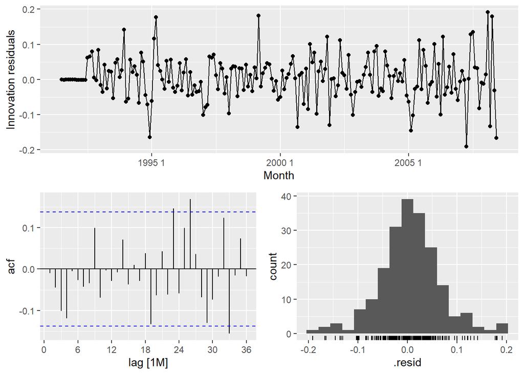

```r
fit <- h02 |>
  model(ARIMA(log(Cost) ~ 0 + pdq(3,0,1) + PDQ(0,1,2)))
fit |> gg_tsresiduals(lag_max=36)
```

Figure 9.25: Innovation residuals from the ARIMA(3,0,1)(0,1,2)$_{12}$ model applied to the H02 monthly script sales data.

```r
augment(fit) |>
  features(.innov, ljung_box, lag = 36, dof = 6)
```

```
## # A tibble: 1 × 3
##   .model                                             lb_stat lb_pvalue
##   <chr>                                                <dbl>     <dbl>
## 1 ARIMA(log(Cost) ~ 0 + pdq(3, 0, 1) + PDQ(0, 1, 2))    50.7    0.0104
```

#### 초기 모델의 한계

- ARIMA(3,0,1)(0,1,2)[12] 모델의 잔차 ACF에 일부 유의미한 스파이크 존재
- **Ljung-Box 검정 실패** → 잔차에 자기상관 존재 가능
- **예측은 가능**하지만, **신뢰구간은 부정확할 수 있음**

#### 자동 ARIMA 모델 결과

- `ARIMA()` 기본 설정: ARIMA(2,1,0)(0,1,1)[12]
- `stepwise = FALSE`, `approximation = FALSE` 설정 시: ARIMA(2,1,3)(0,1,1)[12]
- 그러나 **모든 모델이 Ljung-Box 테스트에서 실패**
- 현실에서는 **완벽히 통과하는 모델을 찾기 어려운 경우도 있음**

#### 테스트셋 예측 평가

- **학습 데이터**: 1991년 7월 ~ 2006년 6월
- **테스트셋**: 2006년 7월 ~ 2008년 6월
- **성능 지표**: RMSE (Root Mean Squared Error)

#### Table 9.3: 테스트셋 RMSE 비교

| 모델 | RMSE |
| --- | --- |
| ARIMA(3,0,1)(1,1,1)[12] | **0.0619** |
| ARIMA(3,0,1)(0,1,2)[12] | 0.0621 |
| ARIMA(2,1,1)(0,1,1)[12] | 0.0622 |
| ARIMA(2,1,2)(0,1,1)[12] | 0.0623 |
| ARIMA(2,1,4)(0,1,1)[12] | 0.0627 |
| ARIMA(2,1,3)(0,1,1)[12] | 0.0628 |
| ARIMA(3,0,1)(0,1,1)[12] | 0.0630 |
| ARIMA(3,0,2)(0,1,1)[12] | 0.0630 |
| ARIMA(2,1,0)(0,1,1)[12] | 0.0630 |
| ARIMA(3,0,1)(0,1,3)[12] | 0.0630 |
| ARIMA(3,0,3)(0,1,1)[12] | 0.0633 |
| ARIMA(3,0,2)(2,1,0)[12] | 0.0651 |
| ARIMA(3,0,1)(2,1,0)[12] | 0.0653 |
| ARIMA(2,1,0)(1,1,0)[12] | 0.0666 |
| ARIMA(3,0,1)(1,1,0)[12] | 0.0666 |
| ARIMA(3,0,0)(2,1,0)[12] | 0.0668 |

- 수동으로 선택한 모델들이 **가장 낮은 RMSE**를 보였으며,
- 자동 ARIMA 모델들도 **성능 차이가 크지 않음**

#### 모델 비교 기준 정리

- **AICc 비교 시**: 차분(d, D)의 순서가 동일한 모델만 비교 가능
- **테스트셋 비교 시**: 차분 여부와 무관하게 **예측 정확도(RMSE)** 비교 가능

#### 최종 모델 및 예측 결과

- **ARIMA(3,0,1)(0,1,2)[12]** 모델은:
  - 테스트셋 RMSE 기준 두 번째로 우수
  - **계절 차분만 사용하는 모델 중 AICc 최고**
- 해당 모델의 예측 결과는 **그림 9.26**에 제시됨

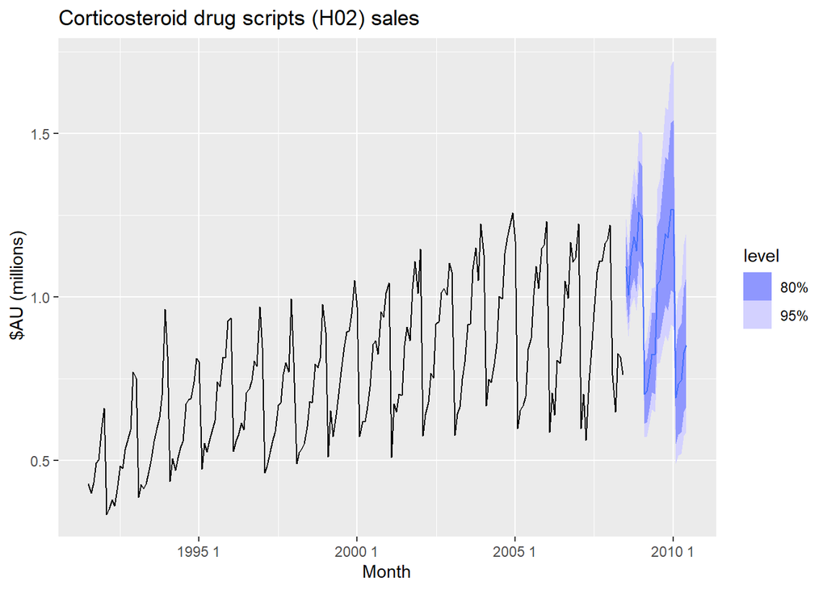

```r
h02 |>
  model(ARIMA(log(Cost) ~ 0 + pdq(3,0,1) + PDQ(0,1,2))) |>
  forecast() |>
  autoplot(h02) +
  labs(y=" $AU (millions)",
       title="Corticosteroid drug scripts (H02) sales")
```

Figure 9.26: Forecasts from the ARIMA(3,0,1)(0,1,2)$_{12}$ model applied to the H02 monthly script sales data.